## 🛠Trabajando con datos: Data Understanding

Cómo lo dice el nombre de la dependencia “Todos Parejos” su trabajo consiste en lograr acercar los medios que permitan el emparajamiento de las condiciones economicas, sociales, de vivienda y de conviviencia en la población.

Para ello, es necesario identificar las causas que generan las diferencias, focalizar a la población con las condiciones más desfavorables y proponer acciones para mejorar sus condiciones para lograr que todos estemos parejos.

Para lograr la identificación y el análisis en la población se requiere trabajar con datos, para es necesario identificar las fuentes, su disponibilidad, su calidad y comenzar a procesarlos para descubrir lo que ellos guardan

**10 Pasos escenciales para la obtención de datos:**

| Nº | Paso | Importancia | Problemas comunes |
| --- | --- | --- | --- |
| 1️⃣ | Identificación de fuentes de datos | Determina dónde están los datos relevantes | Fuentes dispersas, desconocidas o inaccesibles |
| 2️⃣ | Evaluación de la disponibilidad | Verifica si los datos pueden ser obtenidos legal y técnicamente | Restricciones legales, privacidad, permisos de acceso |
| 3️⃣ | Recolección inicial de datos | Primer contacto con los datos reales para exploración preliminar | Volumen excesivo, formatos incompatibles, errores de extracción |
| 4️⃣ | Verificación de integridad | Asegura que los datos estén completos y sin corrupción | Datos faltantes, duplicados, registros corruptos |
| 5️⃣ | Análisis de calidad de datos | Evalúa precisión, consistencia, actualidad y validez | Datos obsoletos, inconsistentes, valores fuera de rango |
| 6️⃣ | Documentación de metadatos | Registra estructura, significado y origen de cada variable | Falta de diccionario de datos, ambigüedad en definiciones |
| 7️⃣ | Identificación de variables clave | Selecciona las variables más relevantes para el problema de negocio | Variables irrelevantes, sesgo en la selección |
| 8️⃣ | Evaluación de sesgos y representatividad | Determina si los datos reflejan adecuadamente la realidad | Muestras no representativas, sesgos históricos |
| 9️⃣ | Transformación preliminar | Limpieza básica: normalización, codificación, corrección de errores | Pérdida de información, errores en la transformación |
| 🔟 | Validación con stakeholders | Revisión con expertos del negocio para asegurar comprensión | Desacuerdos sobre definiciones, falta de alineación |

El trabajo con datos requiere invertir una gran catidad de tiempo en el proceso, hay quienes señalan que en este trabajo se utiliza alrededor del 70% del tiempo de los ingenieros de datos o de los data sciences antes de lograr siquiera producir la primer gráfica descriptiva.

La dependencia cuenta con datos socieconómicos de las familias de la comunidad, información fundamental para caracterizar a la población y poder identificar su perfil.

🧪 ¿Por qué extraer una muestra si tengo todos los datos? Aunque se cuenta con las 16,005 encuestas completas, trabajar con una muestra puede ser metodológicamente valioso y didácticamente potente. Aquí te explico por qué:

- 🎓 1. Simulación inferencial 🔍 Permite recrear el escenario típico en el que no se tiene acceso al universo completo, como ocurre en la mayoría de estudios reales.
- 🧰 2. Validación de métodos 🧪 Facilita la prueba y depuración del flujo de análisis sin procesar todo el conjunto.
- 📚 3. Propósitos didácticos 🧠 Una muestra más pequeña permite visualizaciones más claras y explicaciones más accesibles.
- ⚡ 4. Optimización computacional 🖥️ Algunos métodos como bootstrapping o gráficos interactivos pueden ser pesados con grandes volúmenes. 🚀 Usar una muestra agiliza el procesamiento sin perder representatividad.
- 🧪 5. Diseño experimental 🔬 Se Pueden extraer múltiples muestras para comparar subgrupos, aplicar validación cruzada o simular distintos escenarios.

🧪🧪🧪🧪🧪🧪🧪🧪🧪🧪🧪🧪🧪🧪🧪🧪🧪🧪🧪🧪🧪🧪🧪🧪🧪🧪🧪🧪🧪🧪🧪🧪

🎯 Construcción de la muestra: una aproximación estratificada Para garantizar que los análisis reflejen con fidelidad la estructura poblacional del estado en estudio, se optó por construir una muestra estratificada. Esta decisión responde al interés de preservar la distribución original de la encuesta —aproximadamente 16,005 observaciones— en tres dimensiones clave: el año de levantamiento, el sexo de los encuestados y la región geográfica.

El muestreo estratificado permite mejorar la precisión de las estimaciones al asegurar que cada subgrupo relevante esté adecuadamente representado. Para determinar el tamaño óptimo de la muestra, se utilizaron los siguientes parámetros estadísticos:

### Tamaño poblacional:

- 𝑁= nrow(datos_educ) # Tamaño de la población
- Nivel de confianza: 95% (𝑍=1.96) # Nivel de confianza del 95%
- Proporción esperada: máxima variabilidad (𝑝=0.5) # Proporción esperada (máxima variabilidad)
- Margen de error deseado: 3% (𝑒=0.03) # Margen de error deseado

#### Cálculo del tamaño de muestra sin ajuste **$\displaystyle n_0 = \frac{Z^2 \cdot p \cdot (1 - p)}{e^2}$** **$\displaystyle n_{\text{ajustado}} = \frac{n_0}{1 + \left( \frac{n_0 - 1}{N} \right)}$** Indicador Valor Número de Encuestas 16,005 Tamaño sin ajuste 1,067 Tamaño con ajuste 1,000 Región: 5 regiones Sexo: Hombre, Mujer Año de levantamiento : 2 años Esta metodología no solo mejora la representatividad, sino que también fortalece la validez de los modelos econométricos y de aprendizaje automático que se aplicarán posteriormente. En suma, la muestra estratificada es una herramienta clave para garantizar que los resultados obtenidos puedan informar decisiones públicas y personales con mayor rigor y confianza. Indicador Valor Encuestas de 2022 622 Encuestas de 2023 376 % hombres 46 # hombres 464 % mujeres 54 # mujeres 534 Media ingreso mensual 3,891 Media ingreso mensual hombres 4,259 Media ingreso mensual mujeres 3,572 Mediana ingreso mensual 2,000 Mediana ingreso mensual hombres 2,000 Mediana ingreso mensual mujeres 1,950

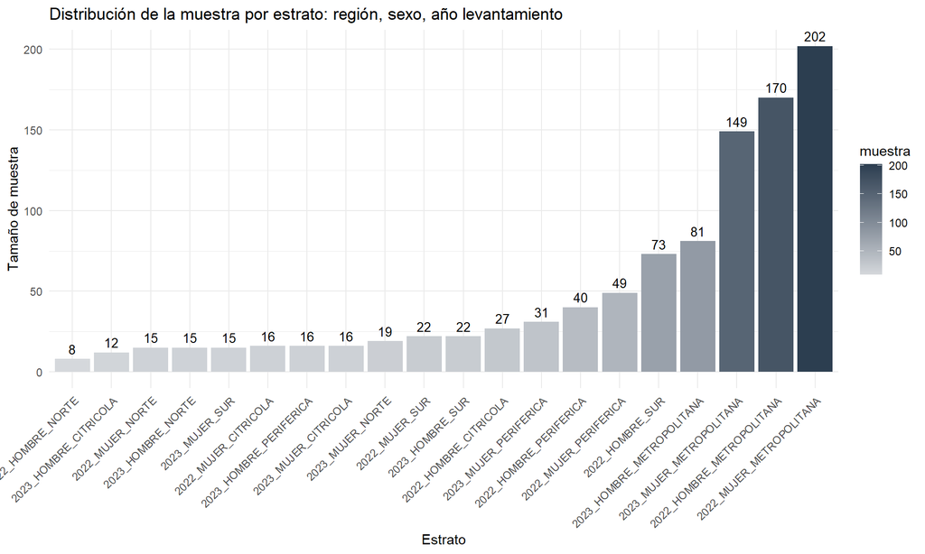

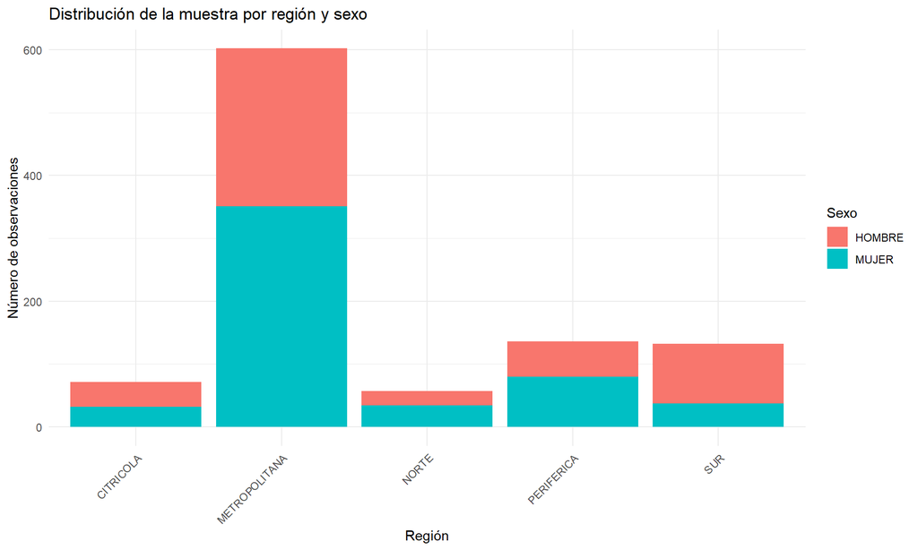

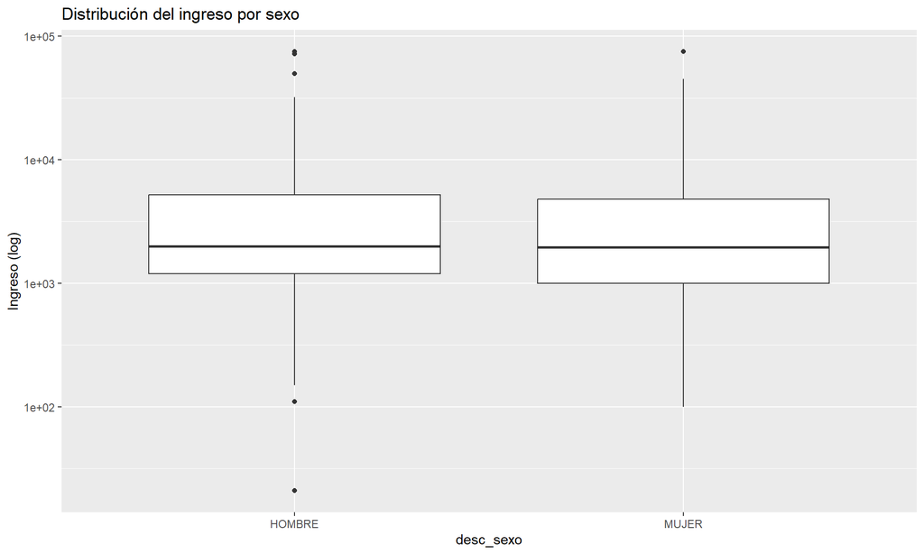